# PeerAssessment2.Rmd

Andreas Johansson

6/30/2016

# Report on major human and economic damage from storm events in the United States from 1950 to 2011

## Synopsis

The U.S. National Oceanic and Atmospheric Administration’s (NOAA) receives and tracks a number of paramaters from storm related events in the United States. This report summarises the storm events resulting in the most damage from a human perspective (direct fatalities and injuries) as well as the economic cost to the economy.

## Data Processing

The storm data covering a period from 1950 to November 2011 was downloaded as a compressed (bz2 format) comma separated file and processed as below:

```r
file_url = "https://d396qusza40orc.cloudfront.net/repdata%2Fdata%2FStormData.csv.bz2"
download.file(file_url, destfile = "StormData.csv.bz2", method = "curl")
data <- read.csv("StormData.csv.bz2", sep = ",", header = TRUE, stringsAsFactors = FALSE)
```

The data contains 902297 events with 37 descriptive parameters. These parameters include the number of fatalites, the number of injuries and the property damage.

Prepare for the data analysis by loading necessary packages:

```r
library(plyr)
library(dplyr)
library(reshape)
```

```r
library(ggplot2)
```

## Results

```r
stats <- ddply(data, c("EVTYPE"), summarise,
  fatal    = sum(FATALITIES, na.rm = TRUE),
  injuries    = sum(INJURIES, na.rm = TRUE),
  propdmg    = sum(PROPDMG, na.rm = TRUE))

stats <- filter(stats, stats$fatal > 0 & stats$injuries > 0 & stats$propdmg > 0)

stats_long <- melt(stats, id.vars = c("EVTYPE"))
```

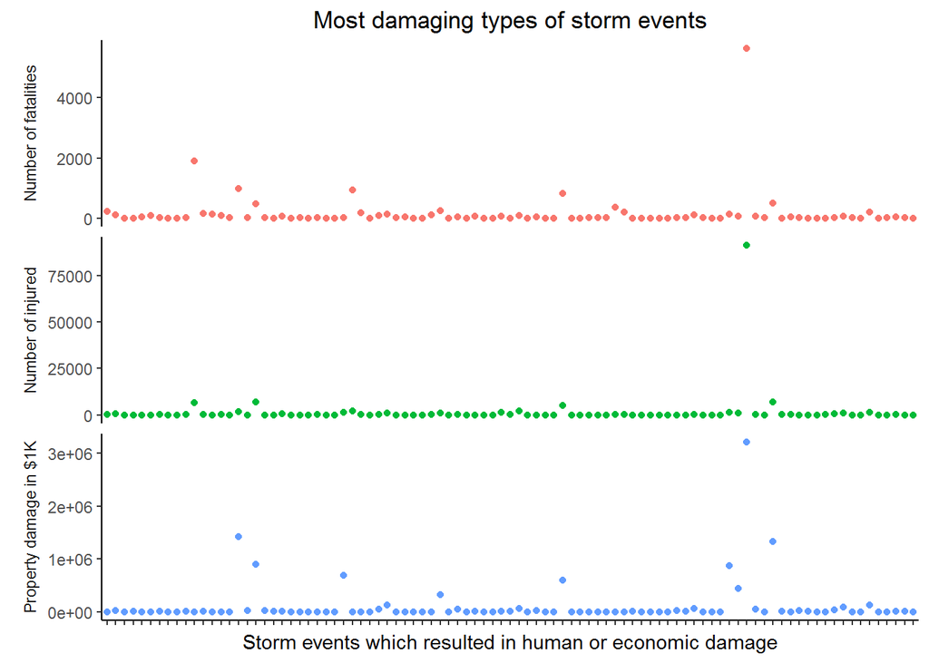

```r
event_labels <- c('fatal' = "Number of fatalities", 'injuries' = "Number of injured", 'propdmg' = "Property damage in $1K")

ggplot(stats_long, aes(EVTYPE, value, fill=variable, colour=variable)) +
  geom_point() +
  facet_grid(variable ~ ., scales = "free", labeller = as_labeller(event_labels), switch = "y") +
  xlab("Storm events which resulted in human or economic damage") +
  ggtitle("Most damaging types of storm events") +
  theme(legend.position="none",
    panel.background = element_blank(),
    axis.title.y = element_blank(),
    axis.text.x  = element_blank(),
    axis.line.x = element_line(color="black"),
    axis.line.y = element_line(color="black"),
    strip.background = element_blank(),
    strip.text = element_text(hjust=0.5)
  )
```

This plot suggests that a small number (~ 10) of events results in a disproportional amount of damage. Filtering for the top ten number of events from each of these three categories will increase the resolution and help us understand which events are the major driving factors.

```r
stats <- stats[order(-stats$fatal),]
top10_fatal <- stats[0:10,]
stats <- stats[order(-stats$injuries),]
top10_injuries <- stats[0:10,]
stats <- stats[order(-stats$propdmg),]
top10_propdmg <- stats[0:10,]

top10_all <- merge(top10_fatal, top10_injuries, all = TRUE)
top10_all <- merge(top10_all, top10_propdmg, all = TRUE)

top10_all_long <- melt(top10_all, id.vars = c("EVTYPE"))
```

The top 10 events for each of the three categories share most but not all events as can be seen in the previous plot. The final list of the most damaging events contains 15 events in total and are shown in the barplot below:

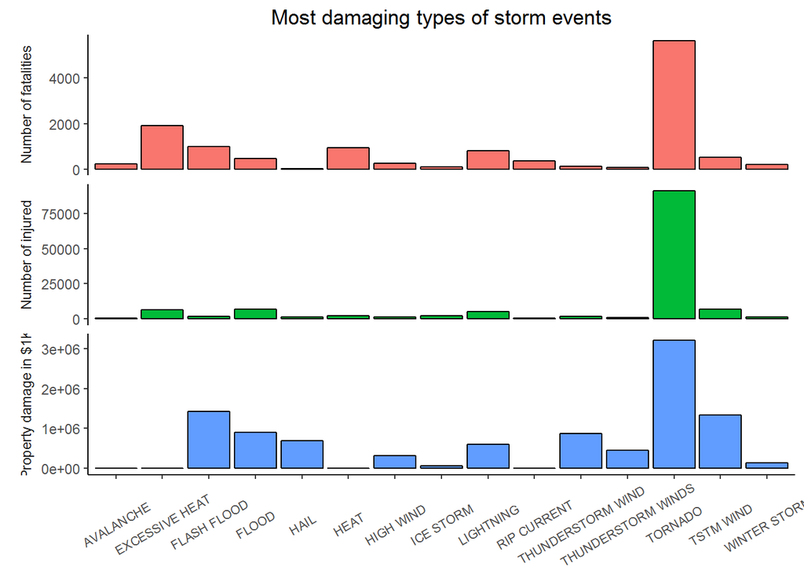

```r
ggplot(data=top10_all_long, aes(x=EVTYPE, y=value, fill=variable)) +
  geom_bar(stat="identity", position=position_dodge(), colour="black") +
  facet_grid(variable ~ ., scales = "free", labeller = as_labeller(event_labels), switch = "y") +
  ggtitle("Most damaging types of storm events") +
  theme(legend.position="none",
    panel.background = element_blank(),
    axis.title.x = element_blank(),
    axis.title.y = element_blank(),
    axis.text.x  = element_text(angle=30, size=8, vjust=0.5),
    axis.line.x = element_line(color="black"),
    axis.line.y = element_line(color="black"),
    strip.background = element_blank(),
    strip.text = element_text(hjust=0.5)
  )
```

The plot clearly shows that the most damaging event (harmful to population health as well as having the greatest economic consequence) results from tornado damage.

The overall most damaging events can be found below:

```r
top10_all
```

```
##                EVTYPE fatal injuries    propdmg
## 1           AVALANCHE   224      170    1623.90
## 2      EXCESSIVE HEAT  1903     6525    1460.00
## 3         FLASH FLOOD   978     1777 1420124.59
## 4               FLOOD   470     6789  899938.48
## 5                HAIL    15     1361  688693.38
## 6                HEAT   937     2100     298.50
## 7           HIGH WIND   248     1137  324731.56
## 8           ICE STORM    89     1975   66000.67
## 9           LIGHTNING   816     5230  603351.78
## 10        RIP CURRENT   368      232       1.00
## 11  THUNDERSTORM WIND   133     1488  876844.17
## 12 THUNDERSTORM WINDS    64      908  446293.18
## 13            TORNADO  5633    91346 3212258.16
## 14          TSTM WIND   504     6957 1335965.61
## 15       WINTER STORM   206     1321  132720.59
```

Tornado damage dominates in all three categories, followed by excessive heat and flash floods for fatalites, thunderstorms (TSTM) and floods for injuries and flash floods and thunderstorms for property damage.

End of report.